# Regression and model validation

*Describe the work you have done this week and summarize your learning.*

For this exercise I will be using data set on student’s learning data collected by Kimmo Vehkalahti. I did some wrangling for the data and my script for that can be seen [here](https://github.com/jokiilk/IODS-project/blob/master/data/create_learning2014.R)

```r
library(GGally)
library(ggplot2)

learning2014 <- read.table("data/learning.csv", sep = ",", header = TRUE)
learning2014$X <- NULL
```

## Data overview

In the first chunk I loaded the needed libraries and read csv data to a data frame. After that I used functions head(), str() and summary() to get a first look of the data.

The data set looks like this:

```r
head(learning2014)
```

```
##   gender Age Attitude Points  deep     surf  stra
## 1      F  53       37     25 3.750 2.583333 3.375
## 2      M  55       31     12 2.875 3.166667 2.750
## 3      F  49       25     24 3.875 2.250000 3.625
## 4      M  53       35     10 3.500 2.250000 3.125
## 5      M  49       37     22 3.750 2.833333 3.625
## 6      F  38       38     21 4.875 2.416667 3.625
```

```r
str(learning2014)
```

```
## 'data.frame':    166 obs. of  7 variables:
##  $ gender  : Factor w/ 2 levels "F","M": 1 2 1 2 2 1 2 1 2 1 ...
##  $ Age     : int  53 55 49 53 49 38 50 37 37 42 ...
##  $ Attitude: int  37 31 25 35 37 38 35 29 38 21 ...
##  $ Points  : int  25 12 24 10 22 21 21 31 24 26 ...
##  $ deep    : num  3.75 2.88 3.88 3.5 3.75 ...
##  $ surf    : num  2.58 3.17 2.25 2.25 2.83 ...
##  $ stra    : num  3.38 2.75 3.62 3.12 3.62 ...
```

```r
summary(learning2014)
```

```
##  gender       Age           Attitude         Points           deep
##  F:110   Min.   :17.00   Min.   :14.00   Min.   : 7.00   Min.   :1.625
##  M: 56   1st Qu.:21.00   1st Qu.:26.00   1st Qu.:19.00   1st Qu.:3.500
##          Median :22.00   Median :32.00   Median :23.00   Median :3.875
##          Mean   :25.51   Mean   :31.43   Mean   :22.72   Mean   :3.796
##          3rd Qu.:27.00   3rd Qu.:37.00   3rd Qu.:27.75   3rd Qu.:4.250
##          Max.   :55.00   Max.   :50.00   Max.   :33.00   Max.   :4.875
##       surf            stra
##  Min.   :1.583   Min.   :1.250
##  1st Qu.:2.417   1st Qu.:2.625
##  Median :2.833   Median :3.188
##  Mean   :2.787   Mean   :3.121
##  3rd Qu.:3.167   3rd Qu.:3.625
##  Max.   :4.333   Max.   :5.000
```

Data set has 166 observations and 7 variables. 3 variables are integers, 3 numericals and 1 variable is a factor with 2 levels.

Data consists of partipants’ background information, their answers and exam points.

Most of the participants were female. Their age was between 17 and 55 years, and the mean age of the participants was 25.51.

And the graphical overview for the data looks like this:

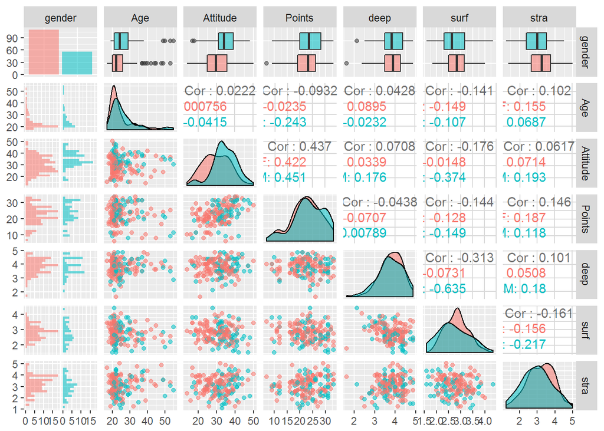

```r
kuvaaja <- ggpairs(learning2014, mapping = aes(col = gender, alpha = 0.3), lower = list(combo = wrap("facethist", bins = 20)))
kuvaaja
```

There are some differences between male and female participants. Male participants are slightly older and their attitude is little bit better.

## Regression model

```r
model <- lm(Points ~ Attitude + stra + deep, data = learning2014)
summary(model)
```

```
##
## Call:
## lm(formula = Points ~ Attitude + stra + deep, data = learning2014)
##
## Residuals:
##     Min      1Q  Median      3Q     Max
## -17.525  -3.342   0.572   3.902  11.646
##
## Coefficients:
##             Estimate Std. Error t value Pr(>|t|)
## (Intercept) 12.05207    3.43928   3.504 0.000592 ***
## Attitude     0.35116    0.05654   6.211 4.27e-09 ***
## stra         0.97852    0.53610   1.825 0.069805 .
## deep        -0.90243    0.72430  -1.246 0.214584
## ---
## Signif. codes:  0 '***' 0.001 '**' 0.01 '*' 0.05 '.' 0.1 ' ' 1
##
## Residual standard error: 5.28 on 162 degrees of freedom
## Multiple R-squared:  0.2124, Adjusted R-squared:  0.1978
## F-statistic: 14.56 on 3 and 162 DF,  p-value: 1.925e-08
```

Model shows that only attitude is good variable for explaining points. Stra is also quite good but the p-value is not small enough.

New regression model with attitude as the only explanatory variable:

```r
model2 <- lm(Points ~ Attitude, data = learning2014)
summary(model2)
```

```
##
## Call:
## lm(formula = Points ~ Attitude, data = learning2014)
##
## Residuals:
##      Min       1Q   Median       3Q      Max
## -16.9763  -3.2119   0.4339   4.1534  10.6645
##
## Coefficients:
##             Estimate Std. Error t value Pr(>|t|)
## (Intercept) 11.63715    1.83035   6.358 1.95e-09 ***
## Attitude     0.35255    0.05674   6.214 4.12e-09 ***
## ---
## Signif. codes:  0 '***' 0.001 '**' 0.01 '*' 0.05 '.' 0.1 ' ' 1
##
## Residual standard error: 5.32 on 164 degrees of freedom
## Multiple R-squared:  0.1906, Adjusted R-squared:  0.1856
## F-statistic: 38.61 on 1 and 164 DF,  p-value: 4.119e-09
```

Multiple R-squared value is 0.1906 and it means that almost 20% of the variance of points can be explained by attitude.

## Validation

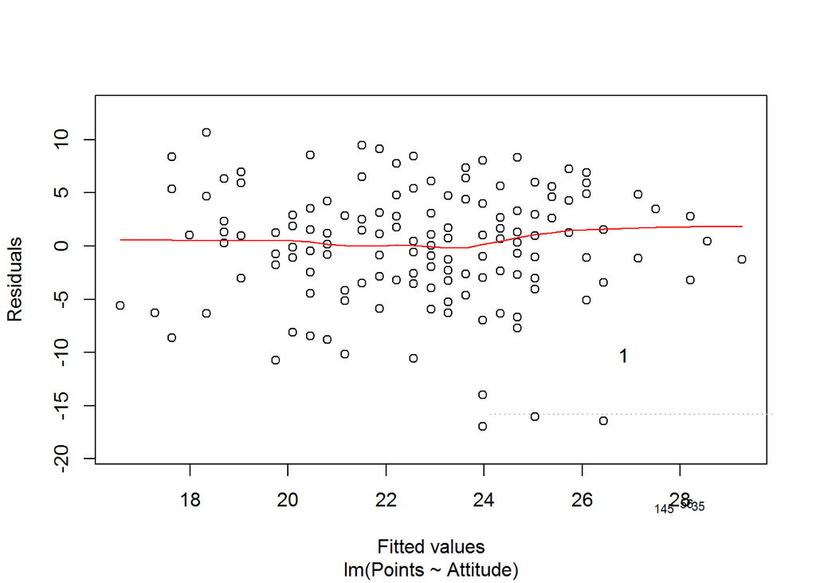

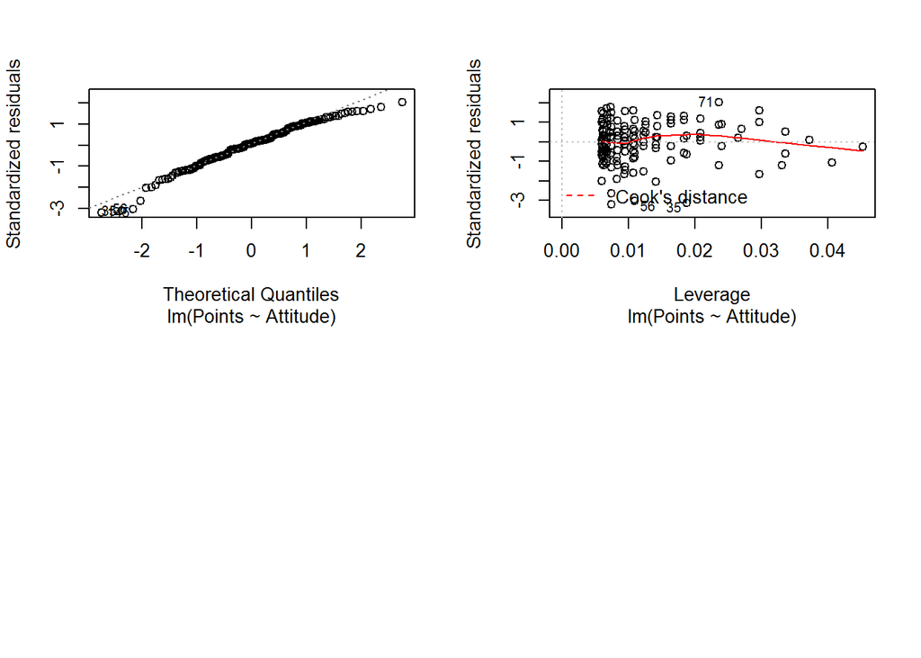

```r
plot(model2, which = c(1,2,5), par(mfrow =c(2,2)))
```